# 📄 Hoja de Trabajo 2

Integrantes

- Diego Alexander Hernández Silvestre - 21270
- Mario Antonio Guerra Morales - 21008
- Linda Inés Jiménez Vides 21169

## 💻 Ejercicio 1

### Preparación del conjunto de datos 📈

```python
import torch
import torch.nn as nn
import torch.optim as optim
from sklearn.datasets import load_iris
from sklearn.model_selection import train_test_split
from sklearn.preprocessing import StandardScaler
from torch.utils.data import DataLoader, TensorDataset
import pandas as pd
import torch.nn.functional as F
import time
import matplotlib.pyplot as plt
import seaborn as sns
```

```python
# Cargar el conjunto de datos de Iris
iris = load_iris()
X = iris.data  # Características
y = iris.target  # Etiquetas

df_iris = pd.DataFrame(data=iris.data, columns=iris.feature_names)

# Dividir el conjunto de datos en entrenamiento y validación
X_train, X_test, y_train, y_test = train_test_split(X, y, test_size=0.3, random_state=42)

# Mostrar los tamaños de los conjuntos resultantes
print(f"Conjunto de entrenamiento: {X_train.shape[0]} muestras")
print(f"Conjunto de validación: {X_test.shape[0]} muestras")
df_iris.head()
```

```
Conjunto de entrenamiento: 105 muestras
Conjunto de validación: 45 muestras
```

|  | sepal length (cm) | sepal width (cm) | petal length (cm) | petal width (cm) |
| --- | --- | --- | --- | --- |
| 0 | 5.1 | 3.5 | 1.4 | 0.2 |
| 1 | 4.9 | 3.0 | 1.4 | 0.2 |
| 2 | 4.7 | 3.2 | 1.3 | 0.2 |
| 3 | 4.6 | 3.1 | 1.5 | 0.2 |
| 4 | 5.0 | 3.6 | 1.4 | 0.2 |

### 🧠 Arquitectura del modelo

```python
# Red neuronal feedforward
class SimpleFeedforwardNN(nn.Module):
    def __init__(self, input_size, hidden_size1, hidden_size2, output_size):
        super(SimpleFeedforwardNN, self).__init__()
        self.fc1 = nn.Linear(input_size, hidden_size1)  # Capa de entrada
        self.fc2 = nn.Linear(hidden_size1, hidden_size2)  # Capa oculta
        self.fc3 = nn.Linear(hidden_size2, output_size)  # Capa de salida

        self.relu = nn.ReLU()  # Función de activación ReLU
        self.softmax = nn.Softmax(dim=1)  # Función de activación Softmax para la capa de salida

    def forward(self, x):
        # Pasar los datos a través de la red
        x = self.relu(self.fc1(x))
        x = self.relu(self.fc2(x))
        x = self.softmax(self.fc3(x))
        return x

# Parámetros de la red
input_size = 4  # Número de características de entrada
hidden_size1 = 10  # Número de neuronas en la primera capa oculta
hidden_size2 = 8  # Número de neuronas en la segunda capa oculta
output_size = 3  # Número de clases de salida

# Instancia de la red neuronal
model = SimpleFeedforwardNN(input_size, hidden_size1, hidden_size2, output_size)

# Mostrar la estructura de la red
print(model)
```

```
SimpleFeedforwardNN(
  (fc1): Linear(in_features=4, out_features=10, bias=True)
  (fc2): Linear(in_features=10, out_features=8, bias=True)
  (fc3): Linear(in_features=8, out_features=3, bias=True)
  (relu): ReLU()
  (softmax): Softmax(dim=1)
)
```

### 📉 Funciones de perdida

```python
# Verificar si CUDA está disponible
device = torch.device("cuda" if torch.cuda.is_available() else "cpu")
print(f"Using device: {device}")
```

```
Using device: cuda
```

```python
# Escalar los datos
scaler = StandardScaler()
X_train = scaler.fit_transform(X_train)
X_test = scaler.transform(X_test)

# Convertir a tensores de PyTorch
X_train_tensor = torch.tensor(X_train, dtype=torch.float32).to(device)
y_train_tensor = torch.tensor(y_train, dtype=torch.long).to(device)
X_test_tensor = torch.tensor(X_test, dtype=torch.float32).to(device)
y_test_tensor = torch.tensor(y_test, dtype=torch.long).to(device)

# Crear DataLoader
train_dataset = TensorDataset(X_train_tensor, y_train_tensor)
test_dataset = TensorDataset(X_test_tensor, y_test_tensor)
train_loader = DataLoader(train_dataset, batch_size=16, shuffle=True)
test_loader = DataLoader(test_dataset, batch_size=16, shuffle=False)
```

```python
def loss_functions():
    # Definir las funciones de pérdida a comparar
    loss_functions = [
        ('CrossEntropy', nn.CrossEntropyLoss()),
        ('MSE', nn.MSELoss()),
        ('NLL', nn.NLLLoss())
    ]

    results = {}

    # Iterar sobre cada función de pérdida
    for loss_name, criterion in loss_functions:
        # Inicializar el modelo y el optimizador
        model = SimpleFeedforwardNN(input_size, hidden_size1, hidden_size2, output_size).to(device)
        optimizer = optim.Adam(model.parameters(), lr=0.01)

        train_losses = []
        test_losses = []
        train_accuracies = []
        test_accuracies = []

        # Entrenamiento durante 100 épocas
        for epoch in range(100):
            model.train()  # Poner el modelo en modo entrenamiento
            outputs = model(X_train_tensor.to(device))  # Hacer una pasada hacia adelante

            # Calcular la pérdida según la función de pérdida
            if loss_name == 'CrossEntropy':
                loss = criterion(outputs, y_train_tensor.to(device))
            elif loss_name == 'NLL':
                log_probs = nn.functional.log_softmax(outputs, dim=1)
                loss = criterion(log_probs, y_train_tensor.to(device))
            else:
                # 'MSE' usa etiquetas one-hot
                loss = criterion(outputs, nn.functional.one_hot(y_train_tensor, num_classes=output_size).float().to(device))

            # Actualizar los gradientes
            optimizer.zero_grad()
            loss.backward()
            optimizer.step()
            train_losses.append(loss.item())

            # Evaluar el modelo
            model.eval()  # Poner el modelo en modo evaluación
            with torch.no_grad():
                test_outputs = model(X_test_tensor.to(device))  # Hacer una pasada hacia adelante en el conjunto de prueba

                # Calcular la pérdida en el conjunto de prueba
                if loss_name == 'CrossEntropy':
                    test_loss = criterion(test_outputs, y_test_tensor.to(device))
                elif loss_name == 'NLL':
                    log_probs = nn.functional.log_softmax(test_outputs, dim=1)
                    test_loss = criterion(log_probs, y_test_tensor.to(device))
                else:
                    # 'MSE' usa etiquetas one-hot
                    test_loss = criterion(test_outputs, nn.functional.one_hot(y_test_tensor, num_classes=output_size).float().to(device))

                test_losses.append(test_loss.item())

                # Calcular la precisión en el conjunto de entrenamiento
                _, predicted_train = torch.max(outputs.data, 1)
                train_accuracy = (predicted_train == y_train_tensor.to(device)).sum().item() / y_train_tensor.size(0)
                train_accuracies.append(train_accuracy)

                # Calcular la precisión en el conjunto de prueba
                _, predicted_test = torch.max(test_outputs.data, 1)
                test_accuracy = (predicted_test == y_test_tensor.to(device)).sum().item() / y_test_tensor.size(0)
                test_accuracies.append(test_accuracy)

        # Almacenar los resultados
        results[loss_name] = {
            'train_loss': train_losses,
            'test_loss': test_losses,
            'train_acc': train_accuracies,
            'test_acc': test_accuracies
        }

    # Imprimir los resultados finales de la última época
    for loss_name, result in results.items():
        final_train_loss = result['train_loss'][-1]
        final_test_loss = result['test_loss'][-1]
        final_accuracy = result['test_acc'][-1]

        print(f"Loss Function: {loss_name}")
        print(f"Final Training Loss: {final_train_loss:.4f}")
        print(f"Final Test Loss: {final_test_loss:.4f}")
        print(f"Accuracy: {final_accuracy:.4f}")
        print()

    return results

results = loss_functions()
```

```
Loss Function: CrossEntropy
Final Training Loss: 0.5784
Final Test Loss: 0.5742
Accuracy: 0.9778

Loss Function: MSE
Final Training Loss: 0.0114
Final Test Loss: 0.0036
Accuracy: 1.0000

Loss Function: NLL
Final Training Loss: 0.5752
Final Test Loss: 0.5633
Accuracy: 1.0000
```

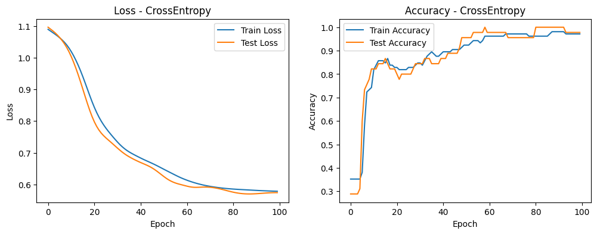

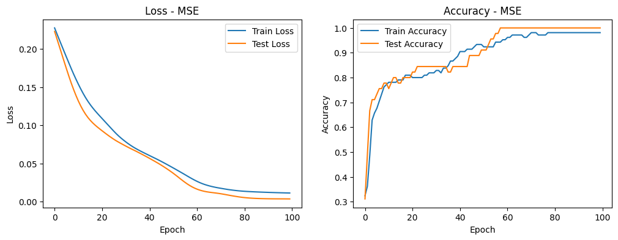

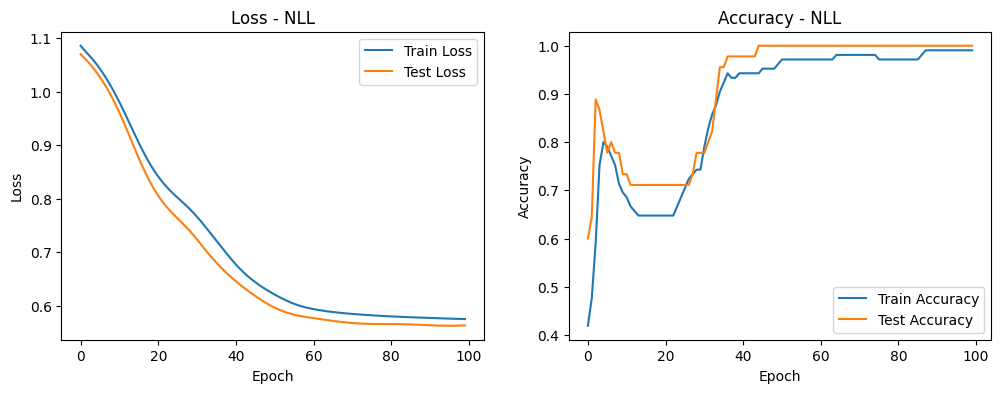

```python
# Graficar los resultados
for loss_name, result in results.items():
    plt.figure(figsize=(12, 4))

    # Gráfica de Pérdida (Loss)
    plt.subplot(1, 2, 1)
    plt.plot(result['train_loss'], label='Train Loss')
    plt.plot(result['test_loss'], label='Test Loss')
    plt.title(f'Loss - {loss_name}')
    plt.xlabel('Epoch')
    plt.ylabel('Loss')
    plt.legend()

    # Gráfica de Precisión (Accuracy)
    plt.subplot(1, 2, 2)
    plt.plot(result['train_acc'], label='Train Accuracy')
    plt.plot(result['test_acc'], label='Test Accuracy')
    plt.title(f'Accuracy - {loss_name}')
    plt.xlabel('Epoch')
    plt.ylabel('Accuracy')
    plt.legend()

    plt.show()
```

### 📊 Técnicas de Regularización

```python
def regularization():
    # Tipos de regularización a evaluar
    reg_types = ['None', 'L1', 'L2', 'Dropout']
    results = {}

    # Iterar sobre cada tipo de regularización
    for reg_type in reg_types:
        # Inicializar el modelo para cada tipo de regularización
        model = SimpleFeedforwardNN(input_size, hidden_size1, hidden_size2, output_size).to(device)

        # Aplicar la regularización según el tipo
        if reg_type == 'Dropout':
            model.fc1 = nn.Sequential(
                model.fc1,
                nn.Dropout(0.5)  # Aplicar Dropout con probabilidad del 50%
            )
            model.fc2 = nn.Sequential(
                model.fc2,
                nn.Dropout(0.5)  # Aplicar Dropout con probabilidad del 50%
            )

        # Definir la función de pérdida y el optimizador
        criterion = nn.CrossEntropyLoss()
        optimizer = optim.Adam(model.parameters(), lr=0.01)

        # Listas para almacenar las pérdidas y precisiones
        train_losses = []
        test_losses = []
        train_accuracies = []
        test_accuracies = []

        # Entrenamiento durante 100 épocas
        for epoch in range(100):
            model.train()  # Poner el modelo en modo entrenamiento
            outputs = model(X_train_tensor.to(device))  # Hacer una pasada hacia adelante

            # Calcular la pérdida
            loss = criterion(outputs, y_train_tensor.to(device))

            # Aplicar regularización L1 o L2 si corresponde
            if reg_type == 'L1':
                l1_lambda = 0.01  # Hiperparámetro de regularización L1
                l1_norm = sum(p.abs().sum() for p in model.parameters())  # Calcular la norma L1
                loss = loss + l1_lambda * l1_norm  # Agregar la regularización L1 a la pérdida
            elif reg_type == 'L2':
                l2_lambda = 0.01  # Hiperparámetro de regularización L2
                l2_norm = sum(p.pow(2.0).sum() for p in model.parameters())  # Calcular la norma L2
                loss = loss + l2_lambda * l2_norm  # Agregar la regularización L2 a la pérdida

            # Actualizar los gradientes
            optimizer.zero_grad()
            loss.backward()
            optimizer.step()

            # Calcular la precisión en el conjunto de entrenamiento
            _, predicted_train = torch.max(outputs.data, 1)
            train_accuracy = (predicted_train == y_train_tensor.to(device)).sum().item() / y_train_tensor.size(0)

            # Evaluar el modelo en el conjunto de prueba
            model.eval()
            with torch.no_grad():
                test_outputs = model(X_test_tensor.to(device))
                test_loss = criterion(test_outputs, y_test_tensor.to(device))
                _, predicted_test = torch.max(test_outputs.data, 1)
                test_accuracy = (predicted_test == y_test_tensor.to(device)).sum().item() / y_test_tensor.size(0)

            # Almacenar los resultados de cada época
            train_losses.append(loss.item())
            test_losses.append(test_loss.item())
            train_accuracies.append(train_accuracy)
            test_accuracies.append(test_accuracy)

        # Almacenar los resultados finales por tipo de regularización
        results[reg_type] = {
            'train_loss': train_losses,
            'test_loss': test_losses,
            'train_acc': train_accuracies,
            'test_acc': test_accuracies
        }

        for reg_type, result in results.items():
            final_train_loss = result['train_loss'][-1]
            final_test_loss = result['test_loss'][-1]
            final_accuracy = result['test_acc'][-1]

            print(f"Loss Function: {reg_type}")
            print(f"Final Training Loss: {final_train_loss:.4f}")
            print(f"Final Test Loss: {final_test_loss:.4f}")
            print(f"Accuracy: {final_accuracy:.4f}")
            print()



    return results

# Llamar la función y obtener los resultados
results = regularization()
```

```
Loss Function: None
Final Training Loss: 0.5749
Final Test Loss: 0.5705
Accuracy: 0.9778

Loss Function: None
Final Training Loss: 0.5749
Final Test Loss: 0.5705
Accuracy: 0.9778

Loss Function: L1
Final Training Loss: 1.1006
Final Test Loss: 1.1017
Accuracy: 0.2889

Loss Function: None
Final Training Loss: 0.5749
Final Test Loss: 0.5705
Accuracy: 0.9778

Loss Function: L1
Final Training Loss: 1.1006
Final Test Loss: 1.1017
Accuracy: 0.2889

Loss Function: L2
Final Training Loss: 0.7890
Final Test Loss: 0.6069
Accuracy: 1.0000

Loss Function: None
Final Training Loss: 0.5749
Final Test Loss: 0.5705
Accuracy: 0.9778

Loss Function: L1
Final Training Loss: 1.1006
Final Test Loss: 1.1017
Accuracy: 0.2889

Loss Function: L2
Final Training Loss: 0.7890
Final Test Loss: 0.6069
Accuracy: 1.0000

Loss Function: Dropout
Final Training Loss: 0.7079
Final Test Loss: 0.5945
Accuracy: 0.9778
```

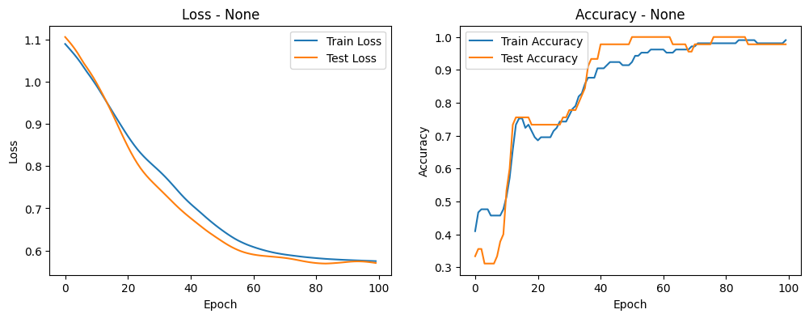

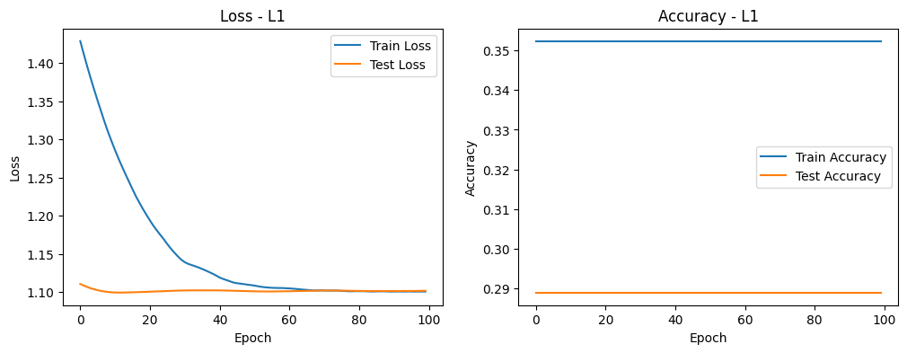

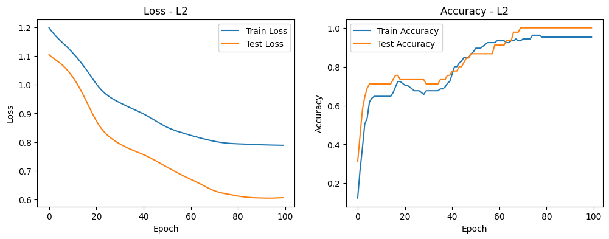

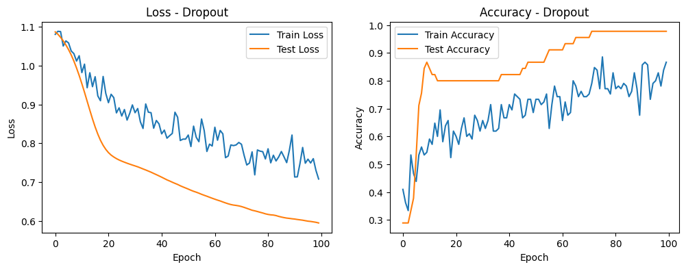

```python
# Graficar los resultados
for reg_type, result in results.items():
    plt.figure(figsize=(12, 4))

    # Gráfica de Pérdida (Loss)
    plt.subplot(1, 2, 1)
    plt.plot(result['train_loss'], label='Train Loss')
    plt.plot(result['test_loss'], label='Test Loss')
    plt.title(f'Loss - {reg_type}')
    plt.xlabel('Epoch')
    plt.ylabel('Loss')
    plt.legend()

    # Gráfica de Precisión (Accuracy)
    plt.subplot(1, 2, 2)
    plt.plot(result['train_acc'], label='Train Accuracy')
    plt.plot(result['test_acc'], label='Test Accuracy')
    plt.title(f'Accuracy - {reg_type}')
    plt.xlabel('Epoch')
    plt.ylabel('Accuracy')
    plt.legend()

    plt.show()
```

### 📈 Algoritmos de Optimización

```python
# Función para entrenar el modelo con distintas técnicas de optimización
def train_with_optimizers(optimizer_name):
    model = SimpleFeedforwardNN(input_size, hidden_size1, hidden_size2, output_size).to(device)
    criterion = nn.CrossEntropyLoss()

    if optimizer_name == 'SGD':
        optimizer = optim.SGD(model.parameters(), lr=0.01)
    elif optimizer_name == 'BatchGD':
        optimizer = optim.SGD(model.parameters(), lr=0.01)
    elif optimizer_name == 'MiniBatchGD':
        optimizer = optim.SGD(model.parameters(), lr=0.01)

    train_losses, test_losses = [], []
    train_accuracies, test_accuracies = [], []

    start_time = time.time()

    for epoch in range(100):
        model.train()
        running_loss = 0.0
        correct = 0
        total = 0

        for inputs, labels in train_loader:
            optimizer.zero_grad()
            outputs = model(inputs)
            loss = criterion(outputs, labels)
            loss.backward()
            optimizer.step()

            running_loss += loss.item()
            _, predicted = torch.max(outputs.data, 1)
            total += labels.size(0)
            correct += (predicted == labels).sum().item()

        train_losses.append(running_loss / len(train_loader))
        train_accuracies.append(correct / total)

        # Validación
        model.eval()
        test_loss = 0.0
        correct = 0
        total = 0

        with torch.no_grad():
            for inputs, labels in test_loader:
                outputs = model(inputs)
                loss = criterion(outputs, labels)
                test_loss += loss.item()

                _, predicted = torch.max(outputs.data, 1)
                total += labels.size(0)
                correct += (predicted == labels).sum().item()

        test_losses.append(test_loss / len(test_loader))
        test_accuracies.append(correct / total)

    end_time = time.time()
    training_time = end_time - start_time

    return train_losses, test_losses, train_accuracies, test_accuracies, training_time
```

```python
# Ejecutar técnicas de optimización con distintos algoritmos.
optimizers = ['SGD', 'BatchGD', 'MiniBatchGD']
results = {}

for optimizer in optimizers:
    train_loss, test_loss, train_acc, test_acc, time_taken = train_with_optimizers(optimizer)
    results[optimizer] = {
        'train_loss': train_loss, 'test_loss': test_loss,
        'train_acc': train_acc, 'test_acc': test_acc,
        'time': time_taken
    }
    print(f"{optimizer} completed in {time_taken:.2f} seconds")
```

```
SGD completed in 4.44 seconds
BatchGD completed in 4.44 seconds
MiniBatchGD completed in 4.39 seconds
```

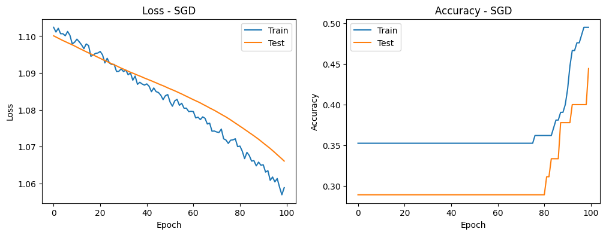

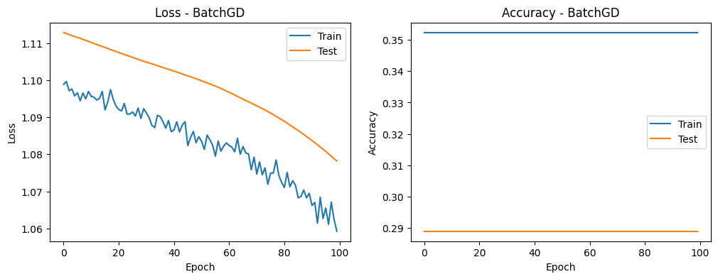

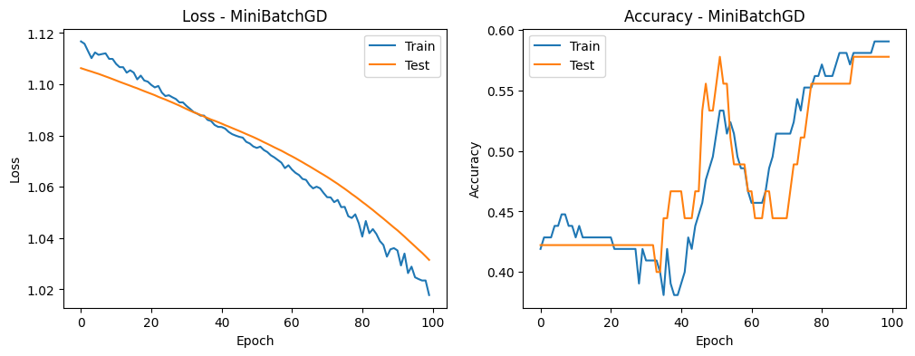

```python
# Gráficos
for optimizer, result in results.items():
    plt.figure(figsize=(12, 4))

    plt.subplot(1, 2, 1)
    plt.plot(result['train_loss'], label='Train')
    plt.plot(result['test_loss'], label='Test')
    plt.title(f'Loss - {optimizer}')
    plt.xlabel('Epoch')
    plt.ylabel('Loss')
    plt.legend()

    plt.subplot(1, 2, 2)
    plt.plot(result['train_acc'], label='Train')
    plt.plot(result['test_acc'], label='Test')
    plt.title(f'Accuracy - {optimizer}')
    plt.xlabel('Epoch')
    plt.ylabel('Accuracy')
    plt.legend()

    plt.show()
```

### 🧪 Experimentación y Análisis

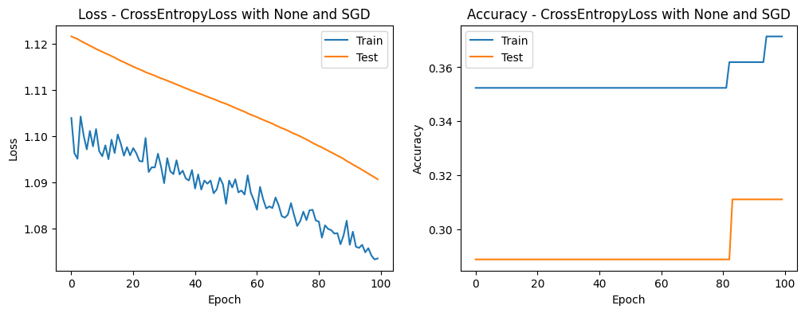

```
Combinación 1:
Función de pérdida: CrossEntropyLoss
Regularización: None
Optimizador: SGD
Tiempo de entrenamiento: 4.45 segundos
Train Loss Final: 1.0735
Test Loss Final: 1.0906
Train Accuracy Final: 0.3714
Test Accuracy Final: 0.3111
==================================================
```

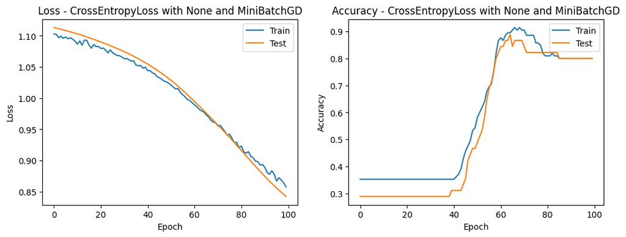

```
Combinación 2:
Función de pérdida: CrossEntropyLoss
Regularización: None
Optimizador: MiniBatchGD
Tiempo de entrenamiento: 4.40 segundos
Train Loss Final: 0.8578
Test Loss Final: 0.8424
Train Accuracy Final: 0.8000
Test Accuracy Final: 0.8000
==================================================
```

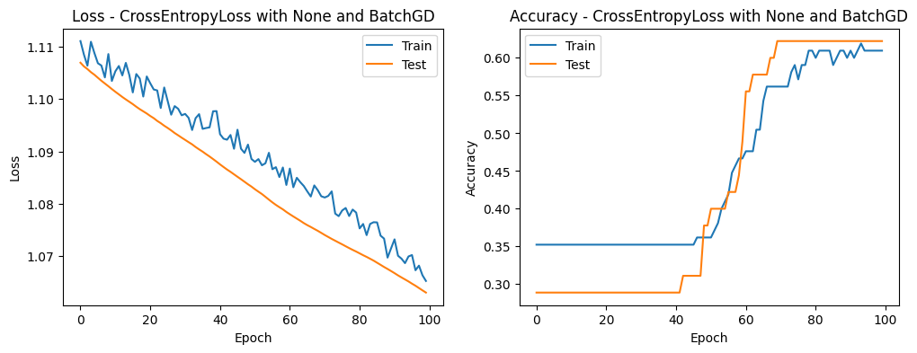

```
Combinación 3:
Función de pérdida: CrossEntropyLoss
Regularización: None
Optimizador: BatchGD
Tiempo de entrenamiento: 4.36 segundos
Train Loss Final: 1.0652
Test Loss Final: 1.0630
Train Accuracy Final: 0.6095
Test Accuracy Final: 0.6222
==================================================
```

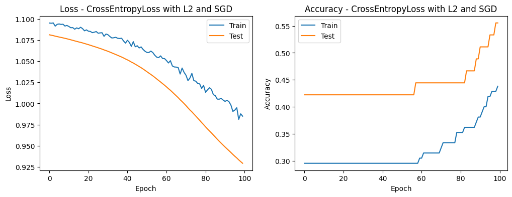

```
Combinación 4:
Función de pérdida: CrossEntropyLoss
Regularización: L2
Optimizador: SGD
Tiempo de entrenamiento: 4.57 segundos
Train Loss Final: 0.9850
Test Loss Final: 0.9293
Train Accuracy Final: 0.4381
Test Accuracy Final: 0.5556
==================================================
```

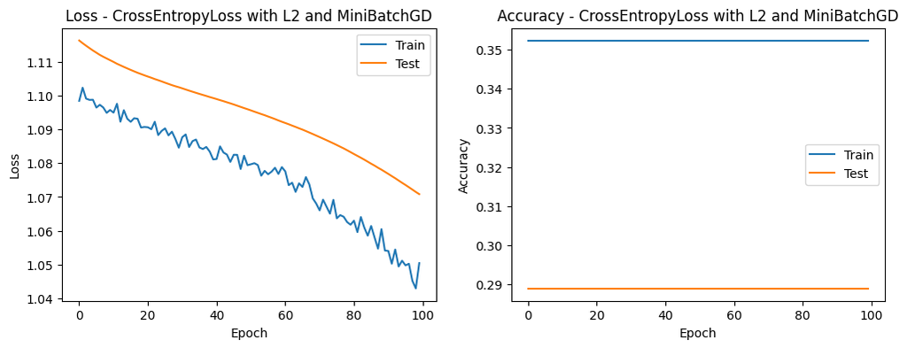

```
Combinación 5:
Función de pérdida: CrossEntropyLoss
Regularización: L2
Optimizador: MiniBatchGD
Tiempo de entrenamiento: 4.42 segundos
Train Loss Final: 1.0505
Test Loss Final: 1.0709
Train Accuracy Final: 0.3524
Test Accuracy Final: 0.2889
==================================================
```

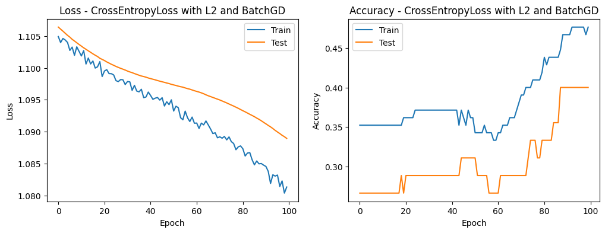

```
Combinación 6:
Función de pérdida: CrossEntropyLoss
Regularización: L2
Optimizador: BatchGD
Tiempo de entrenamiento: 4.35 segundos
Train Loss Final: 1.0813
Test Loss Final: 1.0890
Train Accuracy Final: 0.4762
Test Accuracy Final: 0.4000
==================================================
```

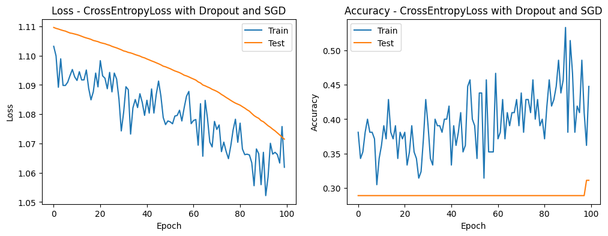

```
Combinación 7:
Función de pérdida: CrossEntropyLoss
Regularización: Dropout
Optimizador: SGD
Tiempo de entrenamiento: 4.76 segundos
Train Loss Final: 1.0619
Test Loss Final: 1.0715
Train Accuracy Final: 0.4476
Test Accuracy Final: 0.3111
==================================================
```

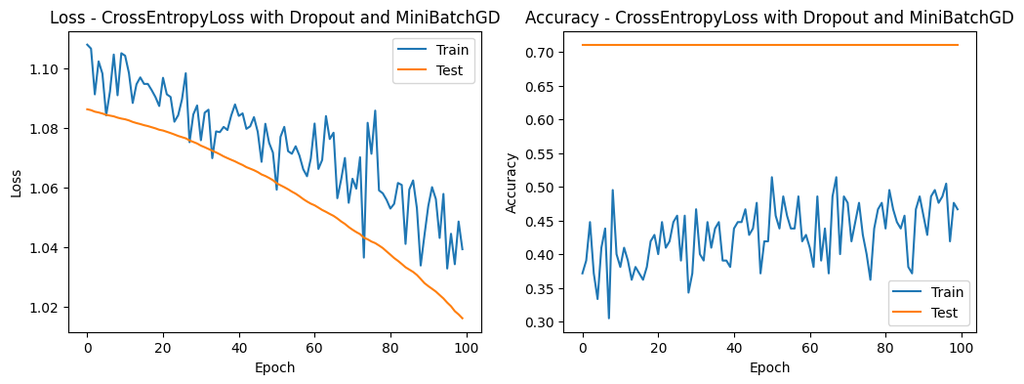

```
Combinación 8:
Función de pérdida: CrossEntropyLoss
Regularización: Dropout
Optimizador: MiniBatchGD
Tiempo de entrenamiento: 4.81 segundos
Train Loss Final: 1.0393
Test Loss Final: 1.0161
Train Accuracy Final: 0.4667
Test Accuracy Final: 0.7111
==================================================
```

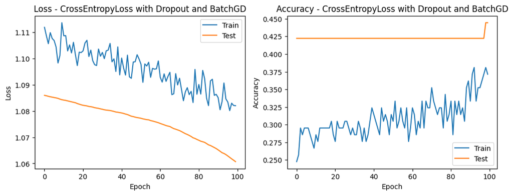

```
Combinación 9:
Función de pérdida: CrossEntropyLoss
Regularización: Dropout
Optimizador: BatchGD
Tiempo de entrenamiento: 4.76 segundos
Train Loss Final: 1.0820
Test Loss Final: 1.0607
Train Accuracy Final: 0.3714
Test Accuracy Final: 0.4444
==================================================
```

```python
def experiment_combinations():
    # Definir combinaciones para entrenamiento.
    loss_functions = [nn.CrossEntropyLoss()]
    regularizations = ['None', 'L2', 'Dropout']
    optimizers = ['SGD', 'MiniBatchGD', 'BatchGD']

    combinations = []
    for loss in loss_functions:
        for reg in regularizations:
            for opt in optimizers:
                combinations.append((loss, reg, opt))

    results = []

    for loss_fn, reg, optimizer_name in combinations:
        # Crear el modelo y asegurarse de que esté en el dispositivo adecuado
        model = SimpleFeedforwardNN(input_size, hidden_size1, hidden_size2, output_size).to(device)

        # Añadir Dropout si corresponde
        if reg == 'Dropout':
            model.fc1 = nn.Sequential(
                model.fc1,
                nn.Dropout(0.5)  # Aplicar Dropout con probabilidad del 50%
            )
            model.fc2 = nn.Sequential(
                model.fc2,
                nn.Dropout(0.5)  # Aplicar Dropout con probabilidad del 50%
            )

        # Configuración del optimizador
        if optimizer_name == 'SGD':
            optimizer = optim.SGD(model.parameters(), lr=0.01)
        elif optimizer_name == 'MiniBatchGD':
            optimizer = optim.SGD(model.parameters(), lr=0.01)
        elif optimizer_name == 'BatchGD':
            optimizer = optim.SGD(model.parameters(), lr=0.01)

        # Aplicar regularización L2 si está seleccionada
        if reg == 'L2':
            optimizer = optim.SGD(model.parameters(), lr=0.01, weight_decay=0.01)

        train_losses, test_losses = [], []
        train_accuracies, test_accuracies = [], []

        start_time = time.time()

        for epoch in range(100):
            model.train()
            running_loss = 0.0
            correct = 0
            total = 0

            for inputs, labels in train_loader:
                # Mover datos al mismo dispositivo que el modelo
                inputs, labels = inputs.to(device), labels.to(device)

                optimizer.zero_grad()
                outputs = model(inputs)
                loss = loss_fn(outputs, labels)
                loss.backward()
                optimizer.step()

                running_loss += loss.item()
                _, predicted = torch.max(outputs.data, 1)
                total += labels.size(0)
                correct += (predicted == labels).sum().item()

            train_losses.append(running_loss / len(train_loader))
            train_accuracies.append(correct / total)

            # Validación
            model.eval()
            test_loss = 0.0
            correct = 0
            total = 0

            with torch.no_grad():
                for inputs, labels in test_loader:
                    inputs, labels = inputs.to(device), labels.to(device)
                    outputs = model(inputs)
                    loss = loss_fn(outputs, labels)
                    test_loss += loss.item()

                    _, predicted = torch.max(outputs.data, 1)
                    total += labels.size(0)
                    correct += (predicted == labels).sum().item()

            test_losses.append(test_loss / len(test_loader))
            test_accuracies.append(correct / total)

        end_time = time.time()
        training_time = end_time - start_time

        results.append({
            'loss_fn': loss_fn.__class__.__name__,
            'regularization': reg,
            'optimizer': optimizer_name,
            'train_loss': train_losses,
            'test_loss': test_losses,
            'train_acc': train_accuracies,
            'test_acc': test_accuracies,
            'time': training_time
        })

    # Graficar los resultados obtenidos.
    for i, result in enumerate(results):
        plt.figure(figsize=(12, 4))

        plt.subplot(1, 2, 1)
        plt.plot(result['train_loss'], label='Train')
        plt.plot(result['test_loss'], label='Test')
        plt.title(f"Loss - {result['loss_fn']} with {result['regularization']} and {result['optimizer']}")
        plt.xlabel('Epoch')
        plt.ylabel('Loss')
        plt.legend()

        plt.subplot(1, 2, 2)
        plt.plot(result['train_acc'], label='Train')
        plt.plot(result['test_acc'], label='Test')
        plt.title(f"Accuracy - {result['loss_fn']} with {result['regularization']} and {result['optimizer']}")
        plt.xlabel('Epoch')
        plt.ylabel('Accuracy')
        plt.legend()

        plt.show()
        print("\n")

        # Imprimir los resultados de cada combinación
        print(f"Combinación {i + 1}:")
        print(f"Función de pérdida: {result['loss_fn']}")
        print(f"Regularización: {result['regularization']}")
        print(f"Optimizador: {result['optimizer']}")
        print(f"Tiempo de entrenamiento: {result['time']:.2f} segundos")
        print(f"Train Loss Final: {result['train_loss'][-1]:.4f}")
        print(f"Test Loss Final: {result['test_loss'][-1]:.4f}")
        print(f"Train Accuracy Final: {result['train_acc'][-1]:.4f}")
        print(f"Test Accuracy Final: {result['test_acc'][-1]:.4f}")
        print("="*50)  # Separador entre combinaciones para mayor claridad

experiment_combinations()
```

### 🗣️ Discusión

Para la primera comparación, **SGD sin regularización**, podemos ver que el tiempo de entrenamiento fue de 4.45 segundos, la convergencia es algo lenta y se puede ver que la presición de entrenamiento y prueba son bastante bajos, por lo que la falta de regularización podría contribuir al sobreajuste del modelo haciendo que los resultados no sean generalizados.

Para la segunda combinación, **MiniBatchGD sin regularización**, se puede apreciar una rápida convergencia entre en conjunto de entrenamiento y prueba. el minibatcgGD por lo general se encuentra en buen equilibrio entre la estabilidad y velocidad de convergencia, el cual aprende más rápido.

Para la quinta combinación, **MiniBatchGD con L2**, podemos ver que a comparación de la versión sin regularización no mejora los resultados ya que la presición es más baja, por lo que sugiere que la regularización de L2 puede esar obstaculizando su capacidad de aprendizaje de patrones útiles.

Para la combinación 6, **BatchGD con L2**, podemos ver un comportamiento parecido al de la combinación 4 pero con una presición todavía más baja. A pesar que la regularización ayuda a evitar el sobreajuste, para BatchGD parece no ser tan adecuada.

## 📚 Ejercicio 2 - Attention Is All You Need

1. **¿Cuál es la principal innovación de la arquitectura Transformer?**

   La arquitectura transformer posee como principal innovación ser el primer modelo que maneja secuencias de datos basado en su totalidad en Attention, con tal de poder procesar los elementos de la secuencia simultáneamente, gracias a la Multi-Headed Self-Attention.
2. **¿Cómo funciona el mecanismo de atención del scaled dot-product?**

   Consiste en queries, keys y values de distintas dimensiones. Se realiza un producto punto entre los queries y keys, posteriormente se divide este producto punto entre los valores de la dimensión de la key en cuestión. Al obtener los resultados, se aplica sobre ellos la función softmax para obtener los pesos de los values.
3. **¿Por qué se utiliza la atención de múltiples cabezales en Transformer?**

   Ya que permite al modelo atender simúltaneamente a información de diferentes subespacios de representación en diferentes posiciones, también mejora el rendiiento del modelo el que diferemtes cabezas se especialicen en diferentes aspectos de la entrada.
4. **¿Cómo se incorporan los positional encodings en el modelo Transformer?**

   Se añaden los embeddings de entrada en la parte inferior de las pilas del encoder y decoder. Estas tienen la misma dimensión que el d_model para que puedan sumarse, utilizando funciones de seno y coseno de diferentes frecuencias para cada dimensión. La elección de funciones sinusoidales permite que el modelo extrapole a secuencias más largas que las encontradas durante el entrenamiento.
5. **¿Cuáles son algunas aplicaciones de la arquitectura Transformer más allá de la machine translation?**

   Se mencionan planes de que se pueda aplicar a problemas que involucren modalidades de entrada y salida distintas de texto como imágenes, audio y video. Otras más alla de las mencionadas puede ser el resumen automático, análisis de sentimientos, reconocimiento de voz, generación de texto, etc.